# Regression and Classification with AMES Housing Data

## 2. Determine any value of *changeable* property characteristics unexplained by the *fixed* ones.

Now that you have a model that estimates the price of a house based on its static characteristics, we can move forward with part 2 and 3 of the plan: what are the costs/benefits of quality, condition, and renovations?

There are two specific requirements for these estimates:

1. The estimates of effects must be in terms of dollars added or subtracted from the house value.
2. The effects must be on the variance in price remaining from the first model.

The residuals from the first model (training and testing) represent the variance in price unexplained by the fixed characteristics. Of that variance in price remaining, how much of it can be explained by the easy-to-change aspects of the property?

**Your goals:**

1. Evaluate the effect in dollars of the renovate-able features.
- How would your company use this second model and its coefficients to determine whether they should buy a property or not? Explain how the company can use the two models you have built to determine if they can make money.
- Investigate how much of the variance in price remaining is explained by these features.
- Do you trust your model? Should it be used to evaluate which properties to buy and fix up?

```python
fixed_df_2 = fixed_df.drop(fixed_df[['SalePrice','YrSold']], axis=1)
fixed_df_2.columns
```

```
Index(['MSSubClass', 'MSZoning', 'Neighborhood', 'LotFrontage', 'LotArea',
       'Street', 'LotShape', 'LandContour', 'LotConfig', 'LandSlope',
       'Condition1', 'Condition2', 'YearBuilt', 'BldgType', 'HouseStyle',
       'Foundation', 'TotalBsmtSF', 'BsmtQual', 'BsmtExposure', '1stFlrSF',
       '2ndFlrSF', 'GrLivArea', 'BsmtFullBath', 'BsmtHalfBath', 'FullBath',
       'HalfBath', 'BedroomAbvGr', 'KitchenAbvGr', 'TotRmsAbvGrd',
       'Fireplaces', 'GarageType', 'GarageCars', 'GarageArea', 'WoodDeckSF',
       'OpenPorchSF', 'EnclosedPorch', '3SsnPorch', 'ScreenPorch', 'PoolArea'],
      dtype='object')
```

```python
# Identify changeable features. Create new DataFrame from original house DataFrame but do not include features that are in the fixed features DataFrame (except for SalePrice)
changeable_df = pd.DataFrame(house.drop(list(fixed_df_2.columns), axis=1))
```

```python
# The following steps will be EDA on the changeable features DataFrame
changeable_df.columns
```

```
Index(['Id', 'Alley', 'Utilities', 'OverallQual', 'OverallCond',
       'YearRemodAdd', 'RoofStyle', 'RoofMatl', 'Exterior1st', 'Exterior2nd',
       'MasVnrType', 'MasVnrArea', 'ExterQual', 'ExterCond', 'BsmtCond',
       'BsmtFinType1', 'BsmtFinSF1', 'BsmtFinType2', 'BsmtFinSF2', 'BsmtUnfSF',
       'Heating', 'HeatingQC', 'CentralAir', 'Electrical', 'LowQualFinSF',
       'KitchenQual', 'Functional', 'FireplaceQu', 'GarageYrBlt',
       'GarageFinish', 'GarageQual', 'GarageCond', 'PavedDrive', 'PoolQC',
       'Fence', 'MiscFeature', 'MiscVal', 'MoSold', 'YrSold', 'SaleType',
       'SaleCondition', 'SalePrice'],
      dtype='object')
```

```python
# Check datatypes
changeable_df.dtypes
```

```
Id                 int64
Alley             object
Utilities         object
OverallQual        int64
OverallCond        int64
YearRemodAdd       int64
RoofStyle         object
RoofMatl          object
Exterior1st       object
Exterior2nd       object
MasVnrType        object
MasVnrArea       float64
ExterQual         object
ExterCond         object
BsmtCond          object
BsmtFinType1      object
BsmtFinSF1         int64
BsmtFinType2      object
BsmtFinSF2         int64
BsmtUnfSF          int64
Heating           object
HeatingQC         object
CentralAir        object
Electrical        object
LowQualFinSF       int64
KitchenQual       object
Functional        object
FireplaceQu       object
GarageYrBlt      float64
GarageFinish      object
GarageQual        object
GarageCond        object
PavedDrive        object
PoolQC            object
Fence             object
MiscFeature       object
MiscVal            int64
MoSold             int64
YrSold             int64
SaleType          object
SaleCondition     object
SalePrice          int64
dtype: object
```

```python
# Check for nulls
changeable_df.isnull().sum()
```

```
Id                  0
Alley            1361
Utilities           0
OverallQual         0
OverallCond         0
YearRemodAdd        0
RoofStyle           0
RoofMatl            0
Exterior1st         0
Exterior2nd         0
MasVnrType          8
MasVnrArea          8
ExterQual           0
ExterCond           0
BsmtCond           37
BsmtFinType1       37
BsmtFinSF1          0
BsmtFinType2       38
BsmtFinSF2          0
BsmtUnfSF           0
Heating             0
HeatingQC           0
CentralAir          0
Electrical          1
LowQualFinSF        0
KitchenQual         0
Functional          0
FireplaceQu       681
GarageYrBlt        79
GarageFinish       79
GarageQual         79
GarageCond         79
PavedDrive          0
PoolQC           1443
Fence            1172
MiscFeature      1398
MiscVal             0
MoSold              0
YrSold              0
SaleType            0
SaleCondition       0
SalePrice           0
dtype: int64
```

```python
# Drop column Id - not required as all values are unique
changeable_df.drop('Id', axis=1, inplace=True)
```

```python
# Remove GarageYrBlt and Alley columns as they are not changeable features
changeable_df.drop(changeable_df[['GarageYrBlt','Alley']], axis=1, inplace=True)
```

```python
#Fill null values for the following features with 'NA', as I'm assuming null values mean that such feature does not exist for the property/house:
#'BsmtCond','BsmtFinType1','BsmtFinType2','FireplaceQu','GarageYrBlt','GarageQual','GarageCond','PoolQC','Fence','MiscFeature'

changeable_df = changeable_df.fillna('NA')
```

```python
# Replace 'NA' values with zero in column MasVnrArea
changeable_df.MasVnrArea.replace('NA', 0, inplace=True)
```

```python
# Remove the following features:
# YearRemodAdd - feature is related to time and not a feature that can be changed or renovate
# MoSold - feature is related to time and not a feature that can be changed or renovate
# MiscFeature - feature is related to fixed feature or it cannot be changed or renovate
# MiscVal - feature is related to MiscFeature (above)
# SaleType - feature is related to fixed feature or it cannot be changed or renovate
# SaleCondition - feature is related to fixed feature or it cannot be changed or renovate

changeable_df.drop(changeable_df[['YearRemodAdd','MoSold','MiscFeature','MiscVal','SaleType','SaleCondition']], axis=1, inplace=True)
```

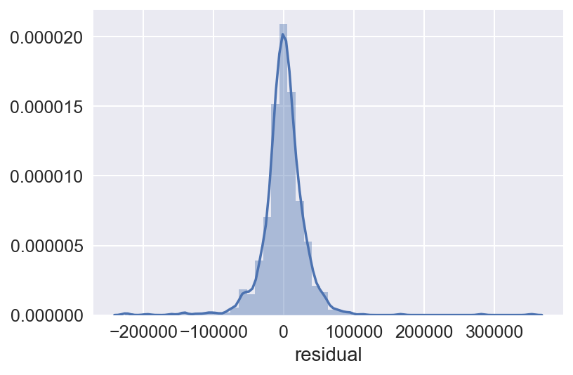

```python
# Get residuals from train set of first model
y_pred_train = ridge_train.predict(X_train)

residual_train = y_pred_train-y_train
sns.distplot(residual_train, axlabel ='residual')
```

```python
# Merge residuals of train and test set
residual = pd.concat([residual_train, residual_test], axis=0)
residual_df = pd.DataFrame({'residual':residual})
residual_df.head()
```

|  | residual |
| --- | --- |
| 0 | -11806.373386 |
| 1 | 48421.097649 |
| 2 | -14033.189663 |
| 3 | 58497.544031 |
| 4 | 68600.595226 |

```python
# Create new dataframe with residual and changeable features
changeable_res_df = pd.concat([changeable_df, residual_df], axis=1)
changeable_res_df.head()
```

|  | Utilities | OverallQual | OverallCond | RoofStyle | RoofMatl | Exterior1st | Exterior2nd | MasVnrType | MasVnrArea | ExterQual | ... | FireplaceQu | GarageFinish | GarageQual | GarageCond | PavedDrive | PoolQC | Fence | YrSold | SalePrice | residual |
| --- | --- | --- | --- | --- | --- | --- | --- | --- | --- | --- | --- | --- | --- | --- | --- | --- | --- | --- | --- | --- | --- |
| 0 | AllPub | 7 | 5 | Gable | CompShg | VinylSd | VinylSd | BrkFace | 196.0 | Gd | ... | NA | RFn | TA | TA | Y | NA | NA | 2008 | 208500 | -11806.373386 |
| 1 | AllPub | 6 | 8 | Gable | CompShg | MetalSd | MetalSd | None | 0.0 | TA | ... | TA | RFn | TA | TA | Y | NA | NA | 2007 | 181500 | 48421.097649 |
| 2 | AllPub | 7 | 5 | Gable | CompShg | VinylSd | VinylSd | BrkFace | 162.0 | Gd | ... | TA | RFn | TA | TA | Y | NA | NA | 2008 | 223500 | -14033.189663 |
| 3 | AllPub | 7 | 5 | Gable | CompShg | Wd Sdng | Wd Shng | None | 0.0 | TA | ... | Gd | Unf | TA | TA | Y | NA | NA | 2006 | 140000 | 58497.544031 |
| 4 | AllPub | 8 | 5 | Gable | CompShg | VinylSd | VinylSd | BrkFace | 350.0 | Gd | ... | TA | RFn | TA | TA | Y | NA | NA | 2008 | 250000 | 68600.595226 |

5 rows × 34 columns